# Proyecto Dataset Médico - Regresión

Ángel Fernandez Temiño

```r
insurance <- read.csv("C:/Users/angel/Desktop/Master UMA/DataScience/Datasets/insurance.csv")
require("corrplot")
age <- insurance[,1]
sex <- insurance[,2]
bmi <- insurance[,3]
children <- insurance[,4]
smoker <- insurance[,5]
region <- insurance[,6]
charges <- insurance[,7]
```

# Predicción de Riesgos.

En este proyecto exploraremos y anañizaremos un conjunto de datos dedicado al costo del tratamiento de diferentes pacientes. El costo del tratamiento depende de muchos factores: diagnóstico, tipo de clínica, ciudad de residencia, edad, etc.

### Estructura del dataset

En este dataset podemos encontrar la siguiente información de cada paciente:

- **Age:** Edad.
- **Sex:** Sexo
- **BMI:** Indice de masa corporal.
- **Children:** El número de hijos.
- **Smoker:** Si es fumador.
- **Region:** Localidad.
- **Charges:** Coste del tratamiento.

```r
summary(insurance)
```

```
##       age            sex           bmi           children     smoker
##  Min.   :18.00   female:662   Min.   :15.96   Min.   :0.000   no :1064
##  1st Qu.:27.00   male  :676   1st Qu.:26.30   1st Qu.:0.000   yes: 274
##  Median :39.00                Median :30.40   Median :1.000
##  Mean   :39.21                Mean   :30.66   Mean   :1.095
##  3rd Qu.:51.00                3rd Qu.:34.69   3rd Qu.:2.000
##  Max.   :64.00                Max.   :53.13   Max.   :5.000
##        region       charges
##  northeast:324   Min.   : 1122
##  northwest:325   1st Qu.: 4740
##  southeast:364   Median : 9382
##  southwest:325   Mean   :13270
##                  3rd Qu.:16640
##                  Max.   :63770
```

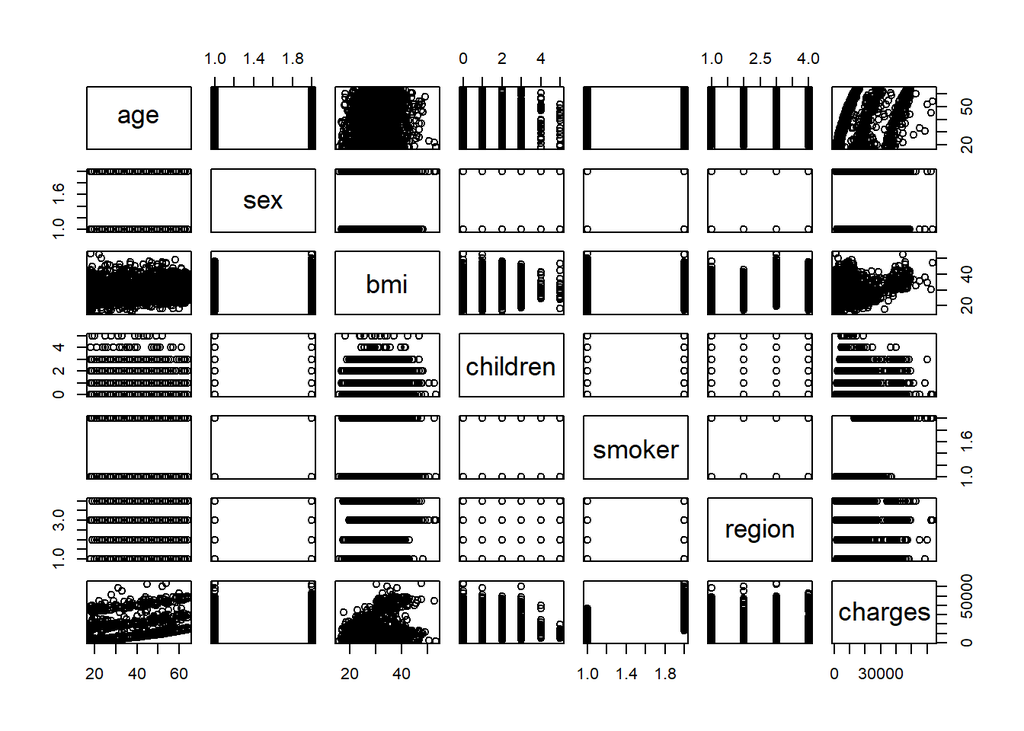

```r
plot(insurance)
```

### Clasificación de las variables del dataset

Como podemos ver tenemos 3 variables catégoricas (*sex*,*smoker*,*regio*), es decir, solo pueden tomar los siguientes valores: **Sex:** male/female. **Smoker:** fumador/no fumador. **Region:** northeast/northwest/southweast/southeast.

Posibles problemas: claramente el conjunto de datos esta desbalanceado, los datos recogidos son mayor parte de personas no fumadoras, esto puede dar a que la media de *charges* sea mayor ya que los pacientes fumadores tienen mas riesgos a tener enfermedades que las pacientes no fumadores.

# Análisis estadístico de los atributos.

En este apartado se va a realizar un analisis mas profundo del dataset, obteniendo asi la distribución de cada uno de los atributos y los posibles sesgos.

### Edad

```r
summary(age)
```

```
##    Min. 1st Qu.  Median    Mean 3rd Qu.    Max.
##   18.00   27.00   39.00   39.21   51.00   64.00
```

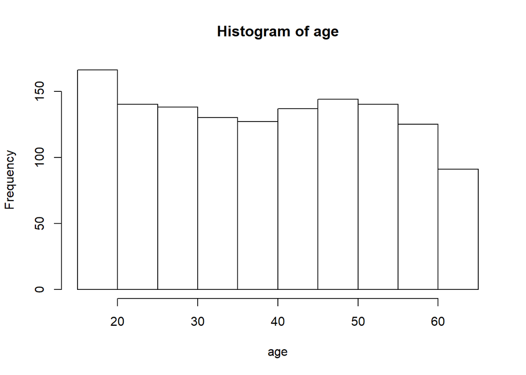

```r
hist(age)
```

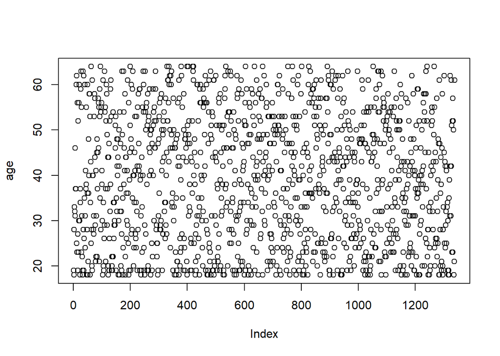

```r
plot(age)
```

Como podemos ver en el histograma y en la representación de datos tenemos conjuntos equitativos por cada intervalo de edad.

### Sexo

```r
sexNumeric <- ifelse(sex=="male", 1, 0)
summary(sexNumeric)
```

```
##    Min. 1st Qu.  Median    Mean 3rd Qu.    Max.
##  0.0000  0.0000  1.0000  0.5052  1.0000  1.0000
```

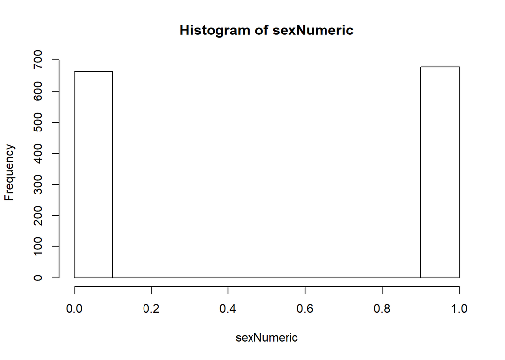

```r
hist(sexNumeric)
```

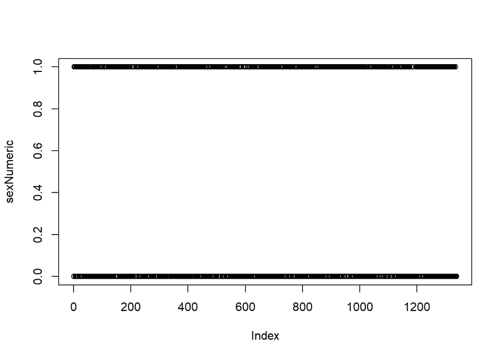

```r
plot(sexNumeric)
```

Ocurre exactamente lo mismo que en el parametro *Age*.

### Bmi

```r
summary(bmi)
```

```
##    Min. 1st Qu.  Median    Mean 3rd Qu.    Max.
##   15.96   26.30   30.40   30.66   34.69   53.13
```

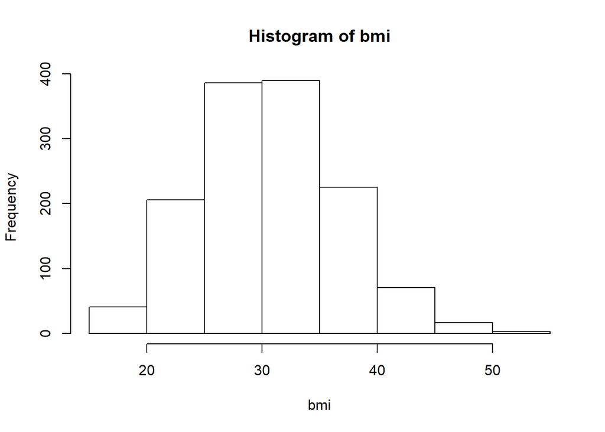

```r
hist(bmi)
```

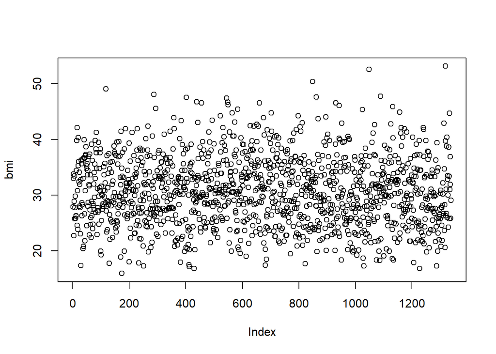

```r
plot(bmi)
```

Podemos apreciar según el histograma, forma de campana de gaus, nos encontramos con una distribución normal y por como explicamos anteriormente, por su media y la relacion con los cuartil.

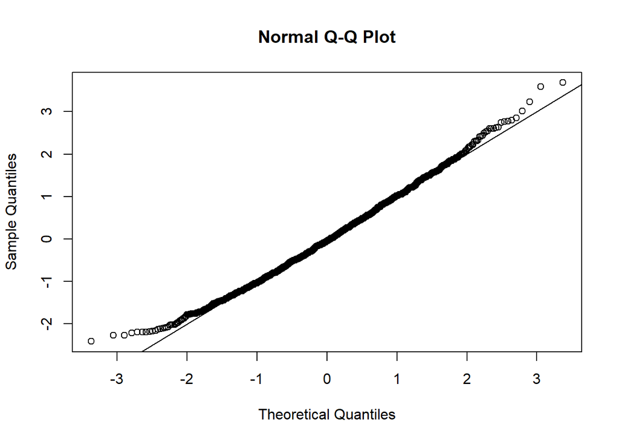

```r
z.norm<-(bmi-mean(bmi))/sd(bmi)
qqnorm(z.norm)
abline(0,1)
```

```r
pnorm(median(bmi), mean = mean(bmi), sd = sd(bmi), lower.tail = TRUE)
```

```
## [1] 0.482774
```

Al representar su normal podemos apreciar que es una función tipica de este tipo de distribución, parece que no tiene sesgo pero tiene algunos valores que no te permiten realizar una afirmación concreta.

### Hijos

```r
summary(children)
```

```
##    Min. 1st Qu.  Median    Mean 3rd Qu.    Max.
##   0.000   0.000   1.000   1.095   2.000   5.000
```

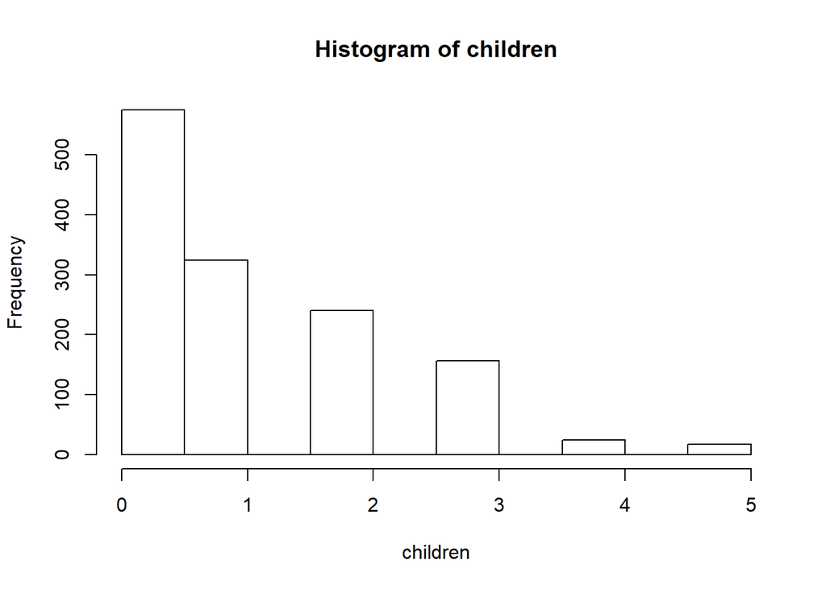

```r
hist(children)
```

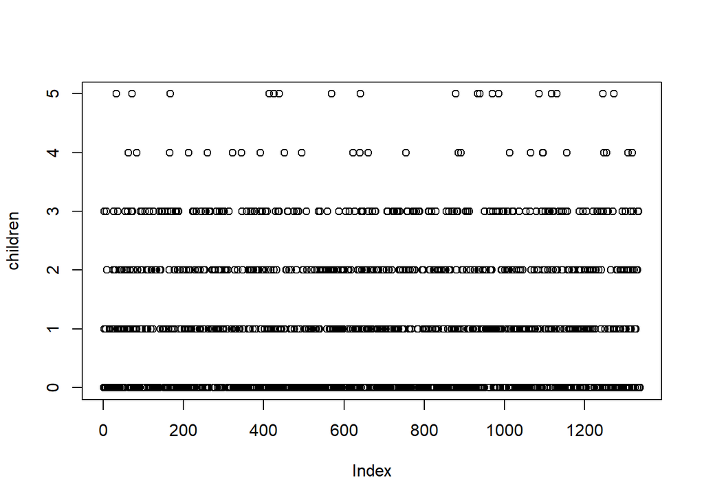

```r
plot(children)
```

### Fumadores

```r
summary(smoker)
```

```
##   no  yes
## 1064  274
```

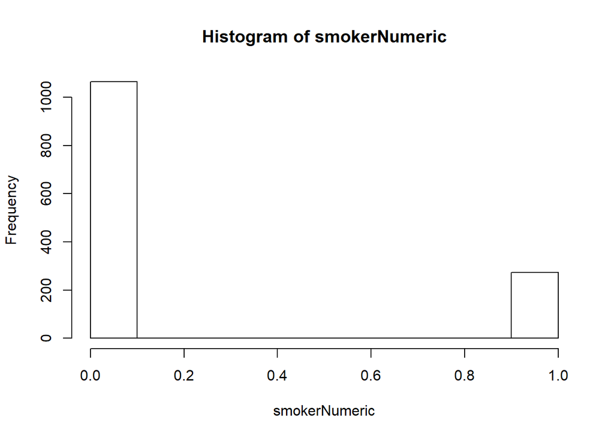

```r
smokerNumeric <- ifelse(smoker=="yes", 1, 0)
hist(smokerNumeric)
```

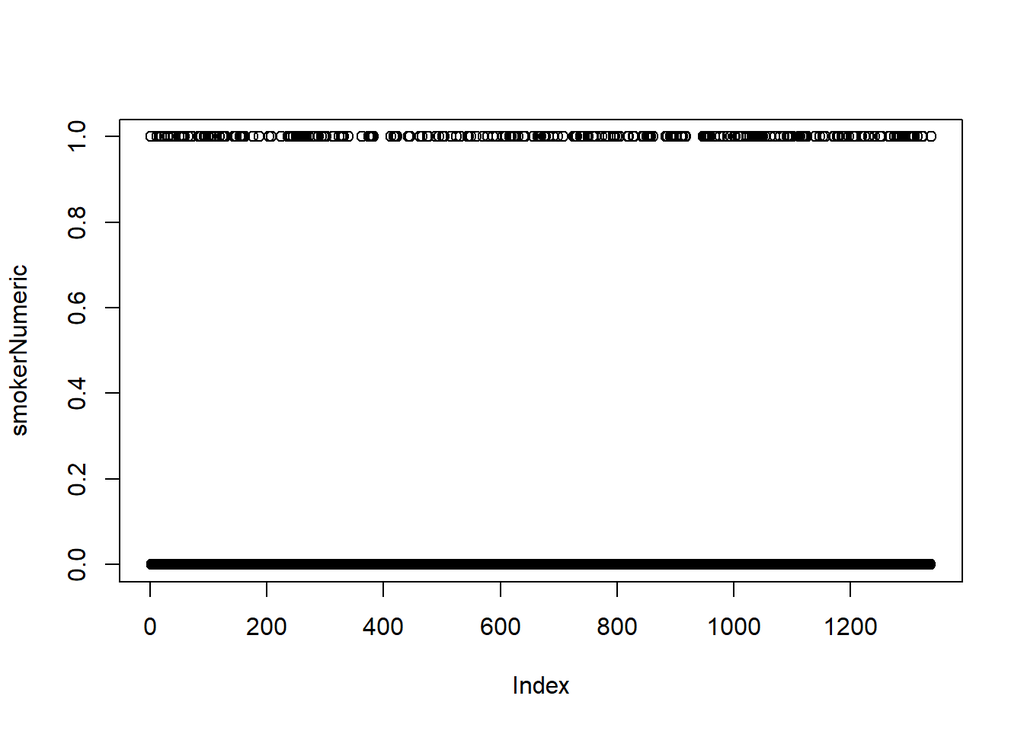

```r
plot(smokerNumeric)
```

Como podemos ver en el histograma y en la representación de datos tenemos conjuntos no equitativos.

### Region

```r
summary(region)
```

```
## northeast northwest southeast southwest
##       324       325       364       325
```

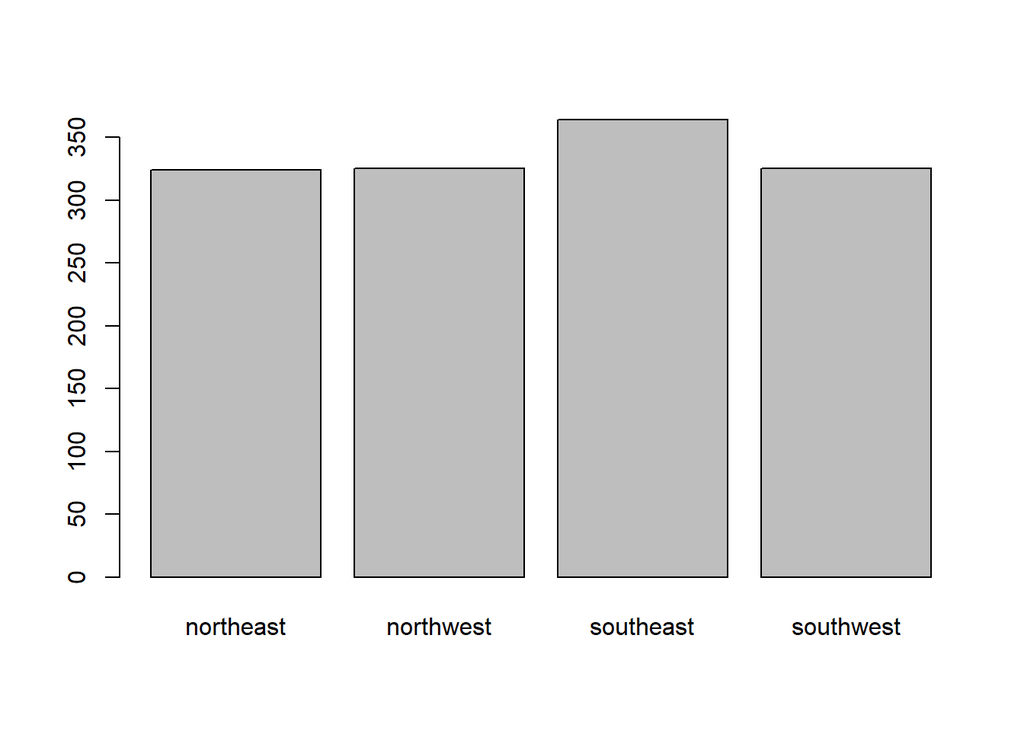

```r
regionNumeric <- as.numeric(region)
plot(region)
```

Como podemos observar hay ligeramente mas pacientes de *sotheast* en el dataset.

### Costes tratamientos

Como se quiere comparar los atributos *charges* y *smoker* vamos a a comparar los costes segun sean fumador o no fumador.

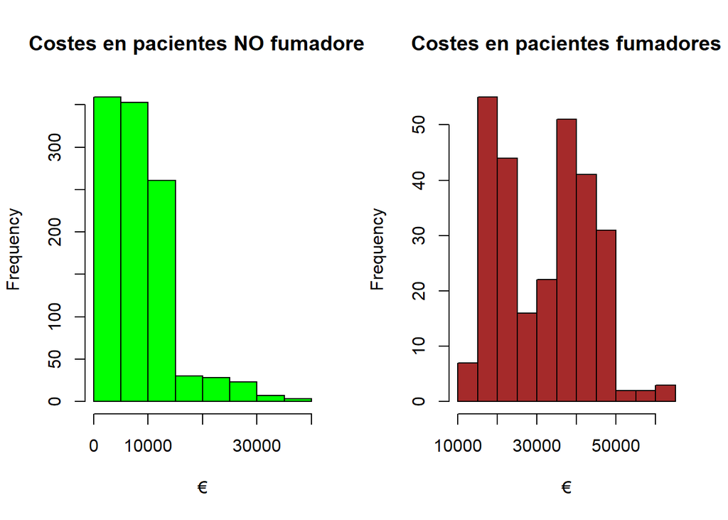

```r
smokerS<-split(insurance, smoker)
par(mfrow=c(1,2))
hist(smokerS$no$charges,
     main = "Costes en pacientes NO fumadores",
     xlab = "€",col = "green")
hist(smokerS$yes$charges,
     main = "Costes en pacientes fumadores",
     xlab = "€", col="brown")
```

#### Boxplot.

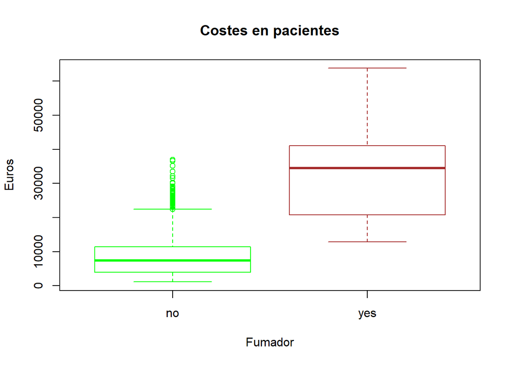

```r
boxplot(charges ~ smoker,
        main = 'Costes en pacientes',
        ylab = 'Euros',
        xlab = 'Fumador',
        border =c("green","brown"))
```

Claramente, en ambas representaciones podemos ver una clara influencia entre ambos atributos, podiendo decir que los costes medios son mayores para los pacientes que SI fuman.

# Matriz de correlación entre los atributos del dataset

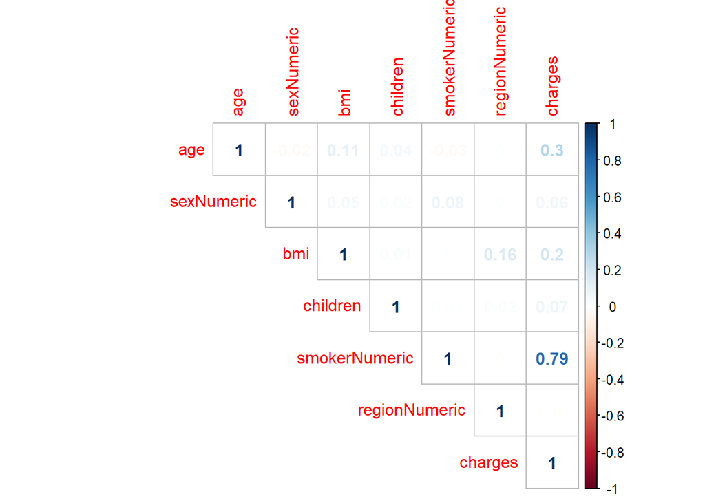

```r
correlacionData<- data.frame(age, sexNumeric, bmi, children, smokerNumeric, regionNumeric, charges)
matrixCorrelacion<-cor(correlacionData)
corrplot(matrixCorrelacion, method ="number",type ="upper")
```

#### Relaciones entre los atributos

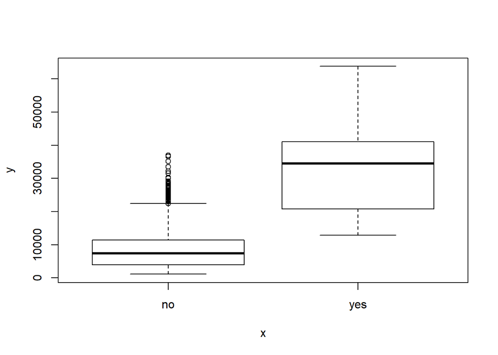

```r
plot(smoker, charges)
```

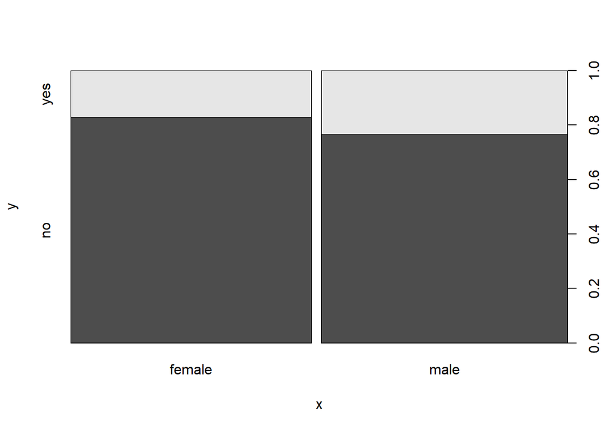

```r
plot(sex,smoker)
```

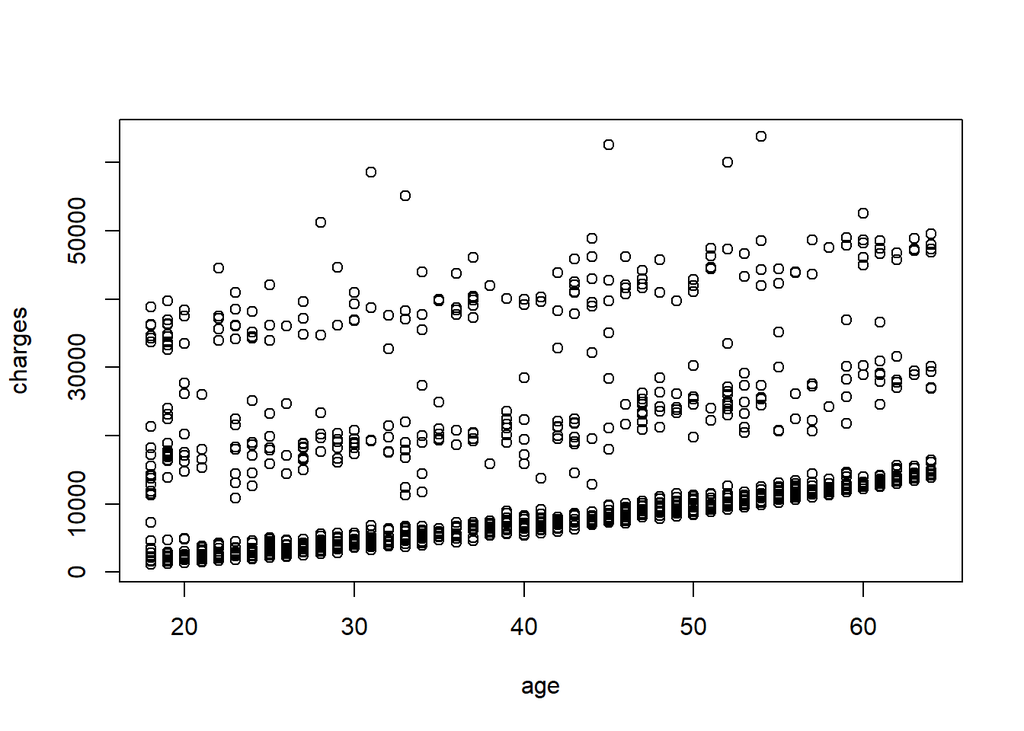

```r
plot(age, charges)
```

### BMI - Distribución

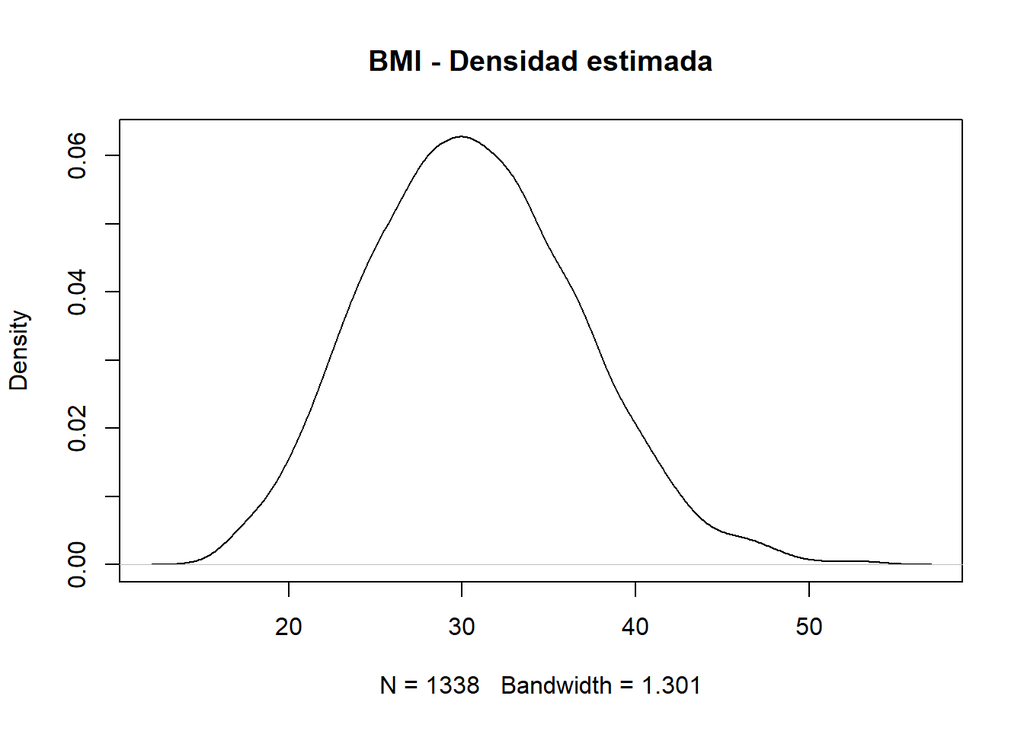

```r
plot(density(bmi),main="BMI - Densidad estimada")
```

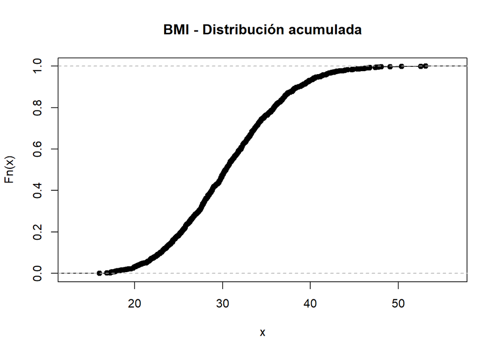

```r
plot(ecdf(bmi),main="BMI - Distribución acumulada")
```

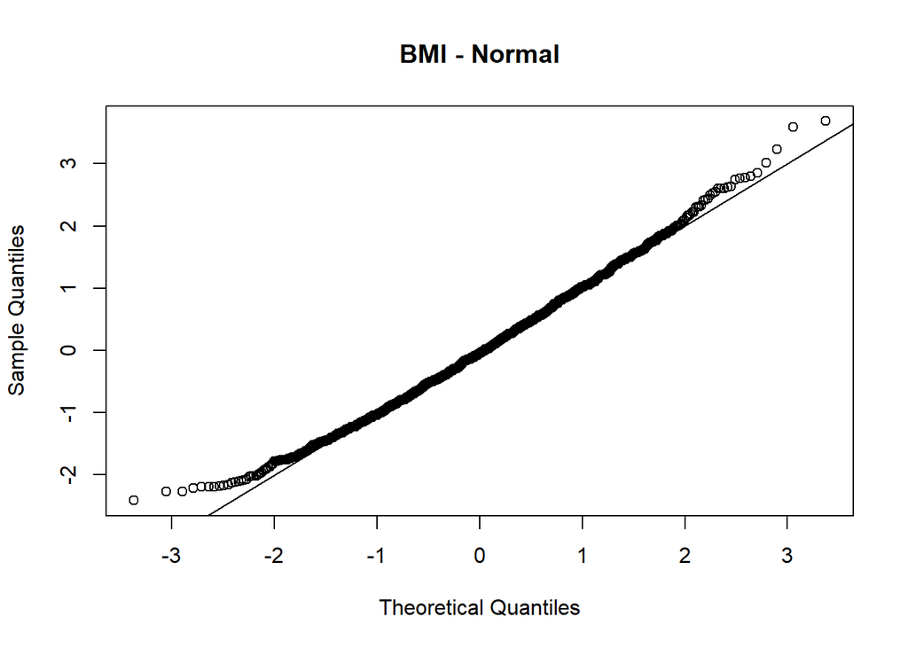

```r
z.norm<-(bmi-mean(bmi))/sd(bmi)
qqnorm(z.norm, main="BMI - Normal")
abline(0,1)
```

Como se puede observar en todas las representaciones, la distribucuón que sigue esta variable es una distribución normal.

### Distribución de los valores del atributo *charges* para los pacientes con bmi>30 (obesidad).

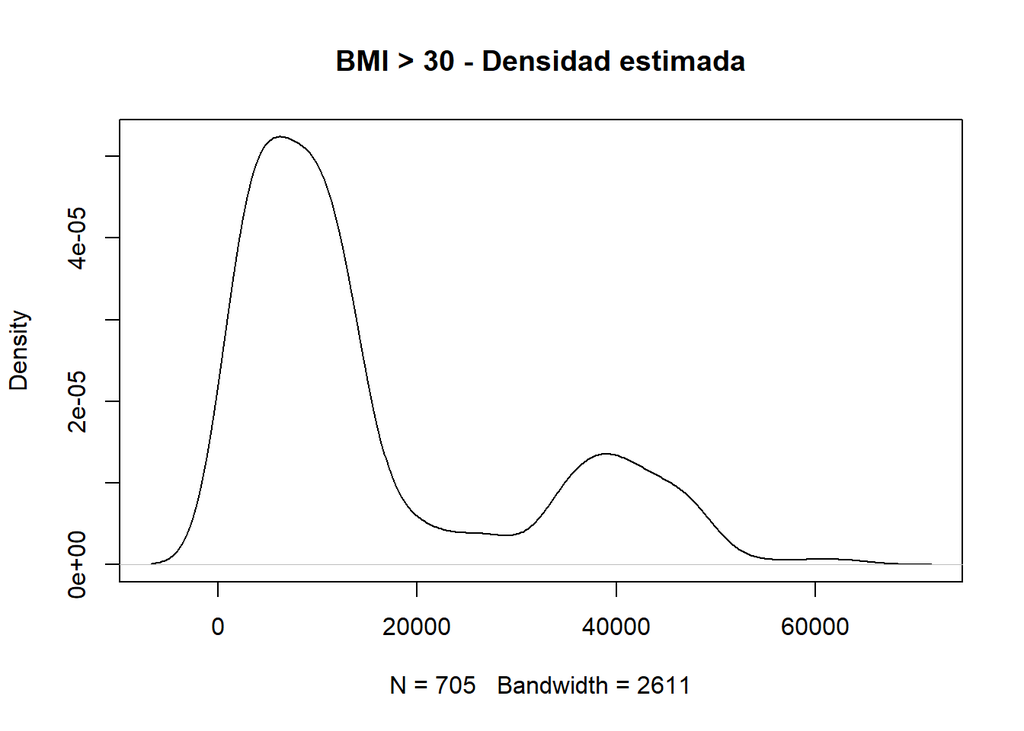

```r
insurance.bmi30<-subset(insurance, bmi>30)
plot(density(insurance.bmi30$charges),main="BMI > 30 - Densidad estimada")
```

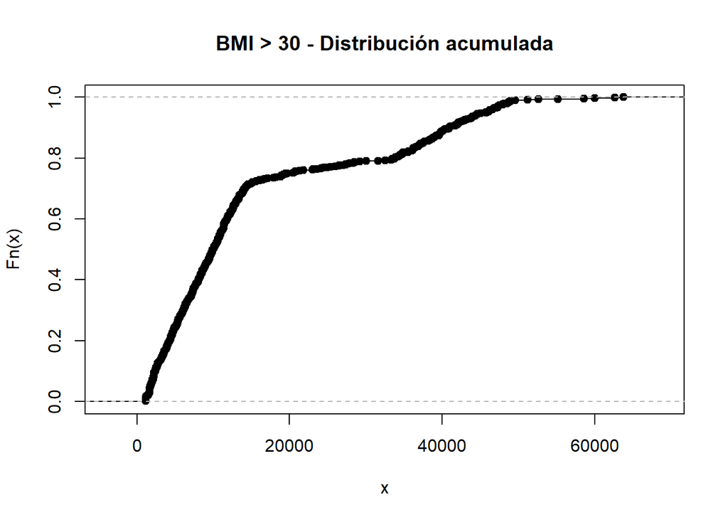

```r
plot(ecdf(insurance.bmi30$charges),main="BMI > 30 - Distribución acumulada")
```

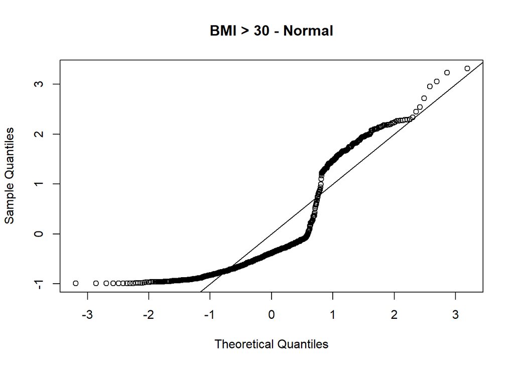

```r
z.norm<-(insurance.bmi30$charges-mean(insurance.bmi30$charges))/sd(insurance.bmi30$charges)
qqnorm(z.norm, main="BMI > 30 - Normal")
abline(0,1)
```

## Modelo Lineal 1 - Charges_BMI.

```r
modLin1 <- lm(charges~bmi,
         data = insurance)
modLin1
```

```
##
## Call:
## lm(formula = charges ~ bmi, data = insurance)
##
## Coefficients:
## (Intercept)          bmi
##      1192.9        393.9
```

```r
summary(modLin1)
```

```
##
## Call:
## lm(formula = charges ~ bmi, data = insurance)
##
## Residuals:
##    Min     1Q Median     3Q    Max
## -20956  -8118  -3757   4722  49442
##
## Coefficients:
##             Estimate Std. Error t value Pr(>|t|)
## (Intercept)  1192.94    1664.80   0.717    0.474
## bmi           393.87      53.25   7.397 2.46e-13 ***
## ---
## Signif. codes:  0 '***' 0.001 '**' 0.01 '*' 0.05 '.' 0.1 ' ' 1
##
## Residual standard error: 11870 on 1336 degrees of freedom
## Multiple R-squared:  0.03934,    Adjusted R-squared:  0.03862
## F-statistic: 54.71 on 1 and 1336 DF,  p-value: 2.459e-13
```

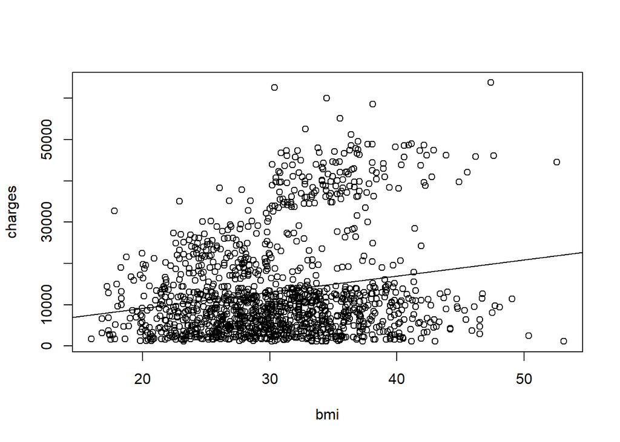

```r
plot(bmi, charges)
abline(modLin1)
```

## Modelo Lineal 2 usando funciones polinómicas - Charges_BMI.

Utilizaremos las mismas varibales para ver su comparacion a posteriori.

```r
modPol1 <- lm(charges ~ bmi + I(bmi^2))
modPol1
```

```
##
## Call:
## lm(formula = charges ~ bmi + I(bmi^2))
##
## Coefficients:
## (Intercept)          bmi     I(bmi^2)
##   -5177.034      813.975       -6.662
```

```r
summary(modPol1)
```

```
##
## Call:
## lm(formula = charges ~ bmi + I(bmi^2))
##
## Residuals:
##    Min     1Q Median     3Q    Max
## -18100  -8152  -3847   4843  49198
##
## Coefficients:
##              Estimate Std. Error t value Pr(>|t|)
## (Intercept) -5177.034   6339.059  -0.817   0.4143
## bmi           813.975    406.889   2.000   0.0456 *
## I(bmi^2)       -6.662      6.397  -1.041   0.2979
## ---
## Signif. codes:  0 '***' 0.001 '**' 0.01 '*' 0.05 '.' 0.1 ' ' 1
##
## Residual standard error: 11870 on 1335 degrees of freedom
## Multiple R-squared:  0.04012,    Adjusted R-squared:  0.03868
## F-statistic:  27.9 on 2 and 1335 DF,  p-value: 1.349e-12
```

## Mejor Modelo Posible

Para realizar el mejor modelo posible tendremos en cuenta todas las variables del dataset.

```r
m3 <- lm(charges ~ ., data = insurance)
summary(m3)
```

```
##
## Call:
## lm(formula = charges ~ ., data = insurance)
##
## Residuals:
##      Min       1Q   Median       3Q      Max
## -11304.9  -2848.1   -982.1   1393.9  29992.8
##
## Coefficients:
##                 Estimate Std. Error t value Pr(>|t|)
## (Intercept)     -11938.5      987.8 -12.086  < 2e-16 ***
## age                256.9       11.9  21.587  < 2e-16 ***
## sexmale           -131.3      332.9  -0.394 0.693348
## bmi                339.2       28.6  11.860  < 2e-16 ***
## children           475.5      137.8   3.451 0.000577 ***
## smokeryes        23848.5      413.1  57.723  < 2e-16 ***
## regionnorthwest   -353.0      476.3  -0.741 0.458769
## regionsoutheast  -1035.0      478.7  -2.162 0.030782 *
## regionsouthwest   -960.0      477.9  -2.009 0.044765 *
## ---
## Signif. codes:  0 '***' 0.001 '**' 0.01 '*' 0.05 '.' 0.1 ' ' 1
##
## Residual standard error: 6062 on 1329 degrees of freedom
## Multiple R-squared:  0.7509, Adjusted R-squared:  0.7494
## F-statistic: 500.8 on 8 and 1329 DF,  p-value: < 2.2e-16
```

Como podemos observar, al incluir el resto de variables en el modelo obtenemos un ajuste del 75% de los datos y tambien podemos destacar cuales son las variables más significativas para él: age, bmi, smoker y children.

## Anova

Para finalizar, utilizando anova, queremos ver que modelo es más interesante.

#### Primer Modelo vs Segundo Modelo

```r
anova(modLin1,modPol1)
```

```
## Analysis of Variance Table
##
## Model 1: charges ~ bmi
## Model 2: charges ~ bmi + I(bmi^2)
##   Res.Df        RSS Df Sum of Sq      F Pr(>F)
## 1   1336 1.8836e+11
## 2   1335 1.8821e+11  1 152903529 1.0846 0.2979
```